# Final Report - Group 01

#### Distribution of Gross Domestic Product (2022)

GDP values in 2022 shows a highly skewed distribution as shown in the histogram and boxplot below. The box plot also shows numerous statistical outliers. This suggests that GDP values in 2022 will need to be transformed before including in the regression model.

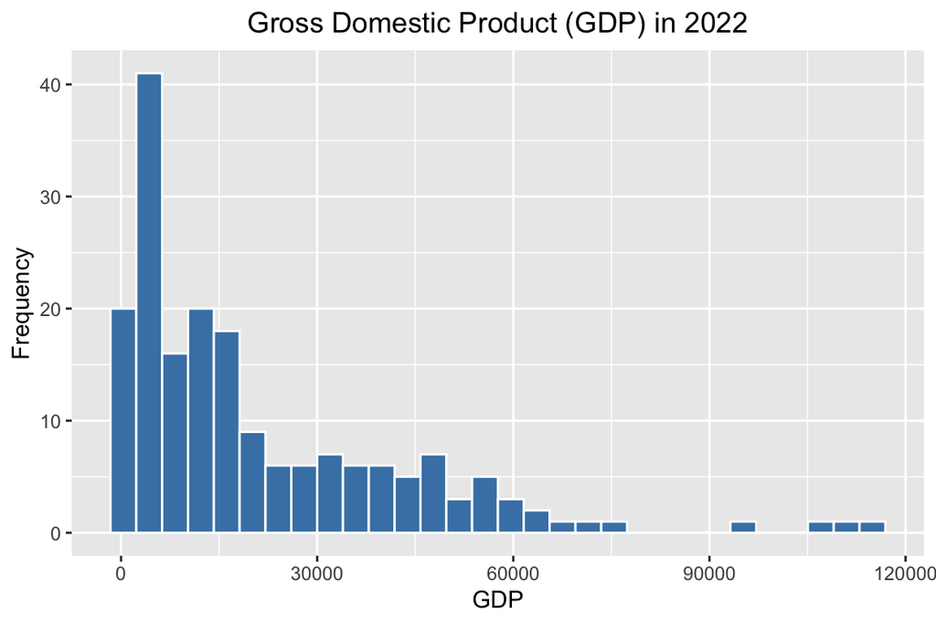

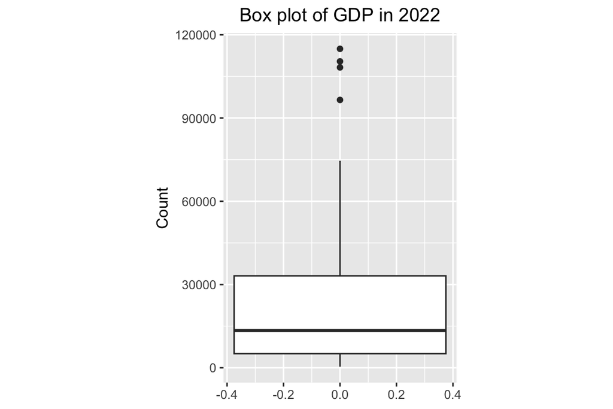

##### Log Transform for 2022 GDP

[figure not shown]

```
##
##  Shapiro-Wilk normality test
##
## data:  data_2022$log_gdp
## W = 0.97764, p-value = 0.004284
```

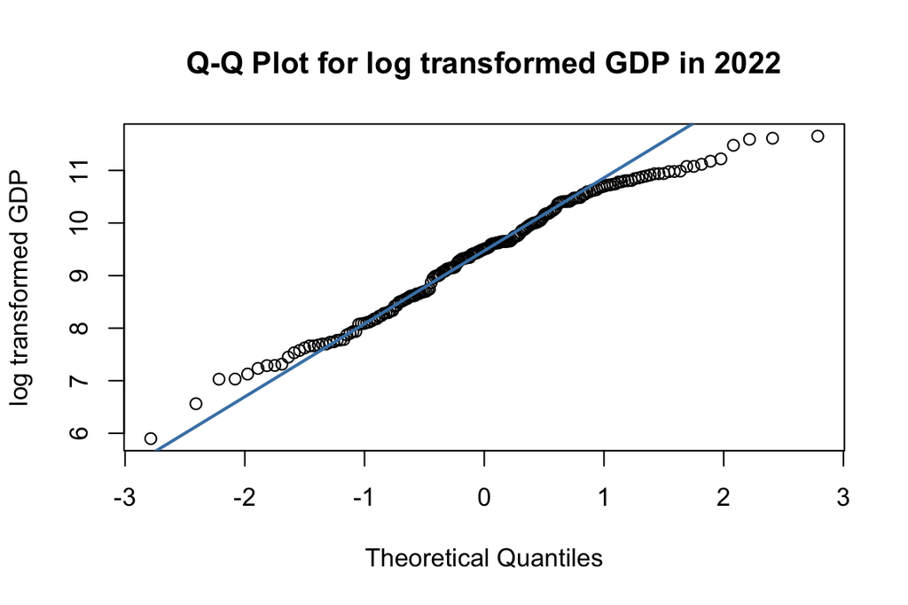

### Distribution of GDP (2011)

The distribution of GDP in 2011 is highly right-skewed, as shown by both the histogram and the box plot. There are several extreme values appear as outliers well above the upper whisker. We will need to transform the data before including it in the model.

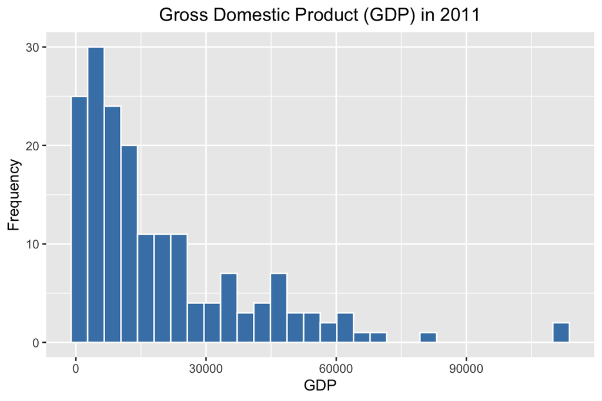

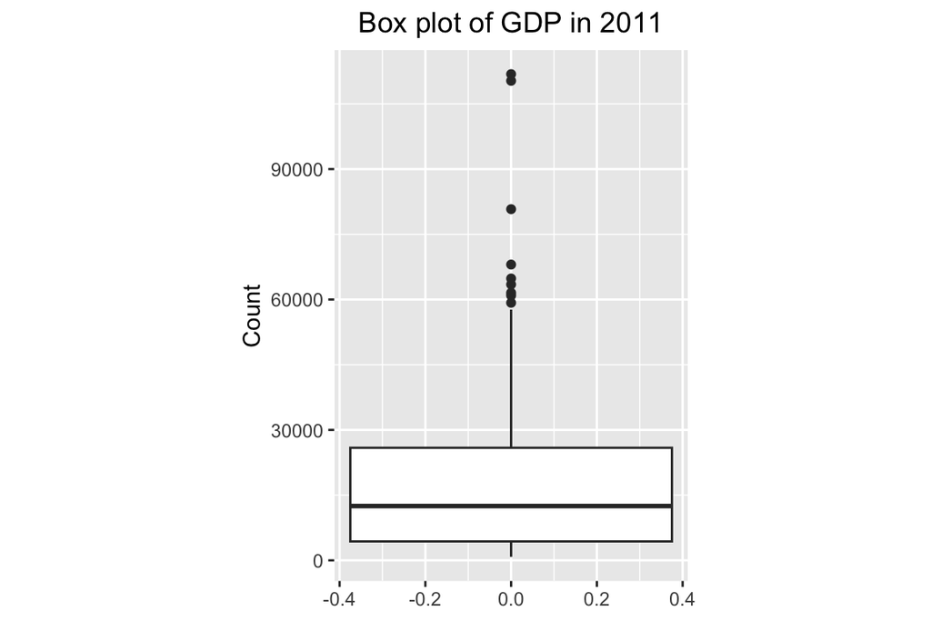

[figure not shown]

```
##
##  Shapiro-Wilk normality test
##
## data:  data_2011$log_gdp
## W = 0.97339, p-value = 0.001804
```

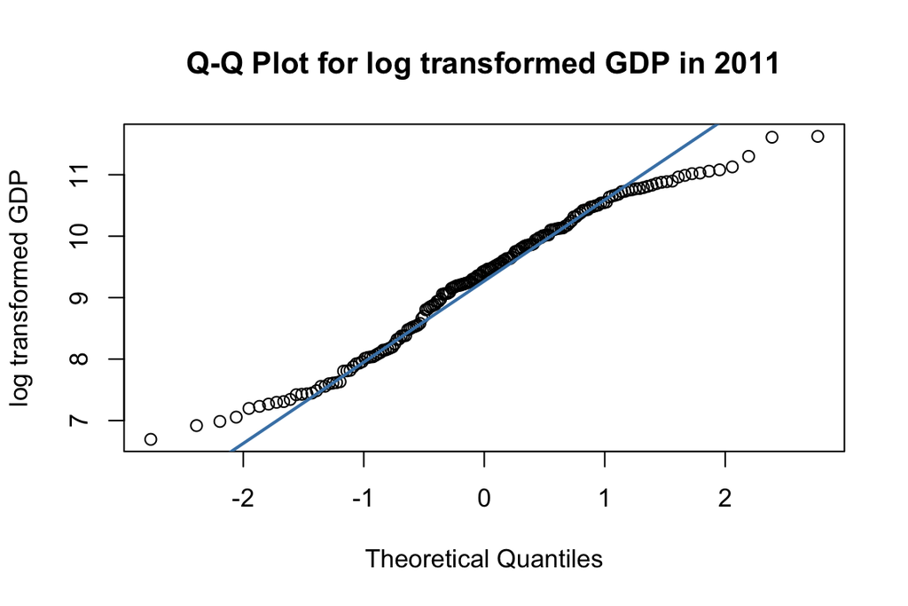

### Standardization

We standardized our data using z-scores to ensure that all variables were equally weighted in our analysis. Standardization is the process of transforming raw values into z-scores, which express each observation relative to the mean and standard deviation of its variable.

For each year (2011 and 2022), we calculated the mean and standard deviation of each variable. Z-scores were computed using the formula z= (x-μ)/σ, where x is the observation value, μ is the mean, and σ is the standard deviation of the variable.

This transformation produced standardized variables with a mean of 0 and standard deviation of 1, allowing for comparisons across our three variables HDI, Broadband access, and GDP.

# Question 1

What is the relationship between HDI and broadband subscriptions, based on the latest available data, which is 2022.

## Descriptives and EDA

### Correlation matrix

Let’s look at the correlations between the independent variables. We want there to be low correlations for no multicollinerity.

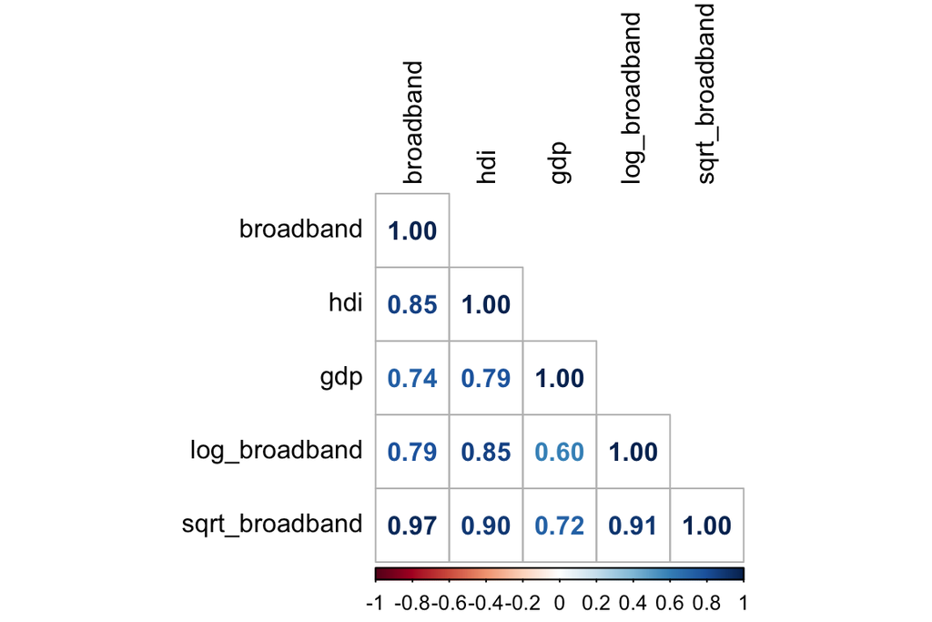

### Plots

#### Scatterplot

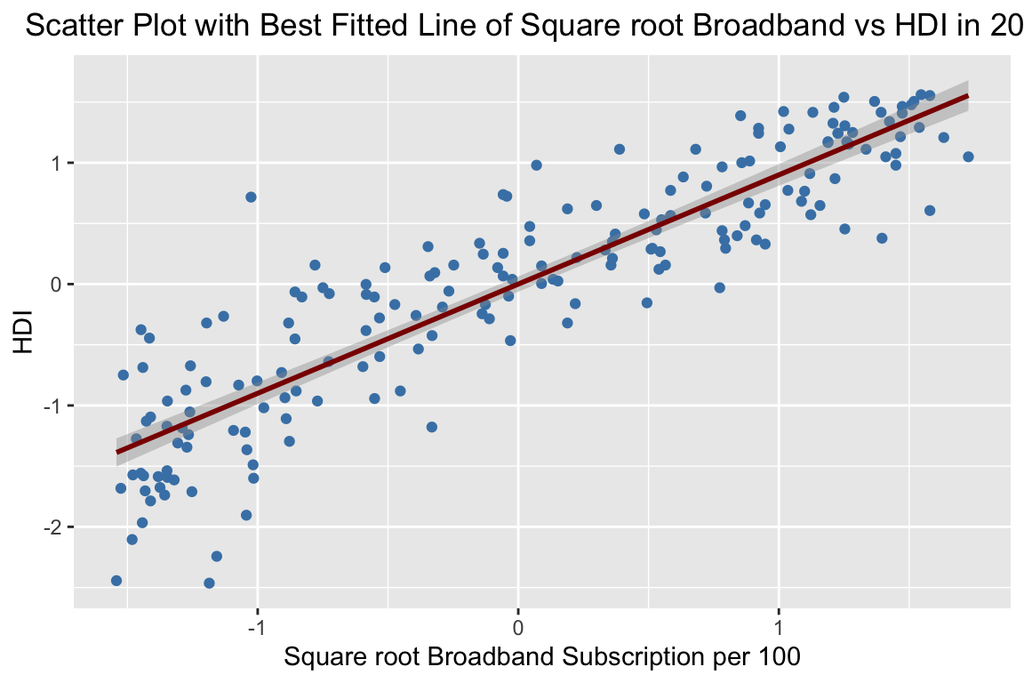

```
##
## Call:
## lm(formula = hdi ~ sqrt_broadband + log_gdp, data = data_2022_standardized)
##
## Residuals:
##      Min       1Q   Median       3Q      Max
## -0.87118 -0.14524  0.02077  0.13574  0.79086
##
## Coefficients:
##                  Estimate Std. Error t value Pr(>|t|)
## (Intercept)    -6.138e-16  1.926e-02    0.00        1
## sqrt_broadband  2.940e-01  3.869e-02    7.60 1.46e-12 ***
## log_gdp         6.991e-01  3.869e-02   18.07  < 2e-16 ***
## ---
## Signif. codes:  0 '***' 0.001 '**' 0.01 '*' 0.05 '.' 0.1 ' ' 1
##
## Residual standard error: 0.2633 on 184 degrees of freedom
## Multiple R-squared:  0.9314, Adjusted R-squared:  0.9307
## F-statistic:  1249 on 2 and 184 DF,  p-value: < 2.2e-16
```

# Question 2

Are there countries that significantly deviate from this relationship between HDI and broadband subscription rate?

| country | broadband | hdi | gdp | log_broadband | sqrt_broadband | log_gdp | fitted_hdi | residuals | std_resid |
| --- | --- | --- | --- | --- | --- | --- | --- | --- | --- |
| Kiribati | -1.061950 | -0.6869171 | -0.8735091 | -2.0278882 | -1.440762 | -1.507936 | -1.477781 | 0.7908639 | 3.030602 |
| Mali | -1.015678 | -2.2428813 | -0.8699118 | -0.9032873 | -1.157119 | -1.475497 | -1.371702 | -0.8711793 | -3.337370 |

Our outliers in 2022 are Kiribati and Mali

# Question 3

How has broadband access by country changed between 2011, when the UN declaration was announced, and 2022?

## Descriptives and EDA

### Plots

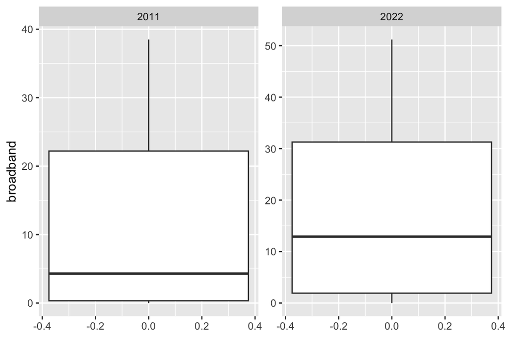

## T-test

```
## [1] -9.393962 -3.880547
## attr(,"conf.level")
## [1] 0.95
```

| lower_ci | upper_ci |
| --- | --- |
| -2.765626 | 2.932945 |

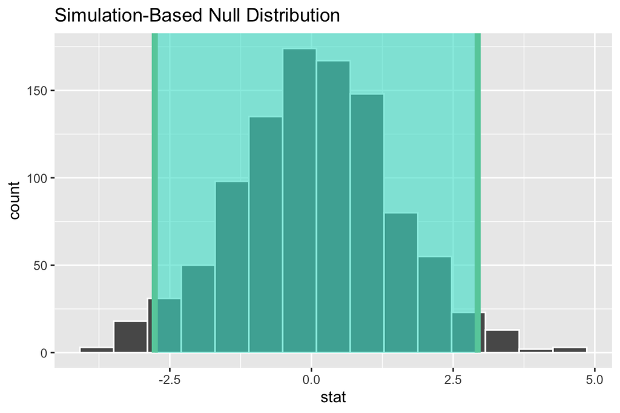

## Wilcoxin-test

```
##
##  Wilcoxon rank sum test with continuity correction
##
## data:  data_2011$broadband and data_2022$broadband
## W = 12189, p-value = 1.391e-05
## alternative hypothesis: true location shift is not equal to 0
```

| lower_ci | upper_ci |
| --- | --- |
| -4.78 | 4.73425 |

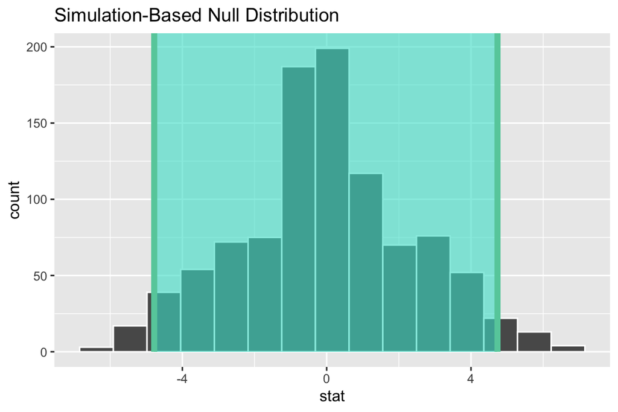

#### Scatterplot

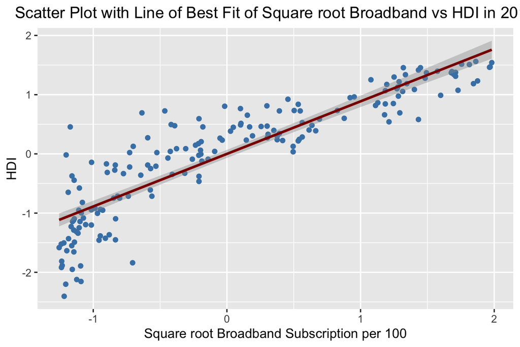

```
##
## Call:
## lm(formula = hdi ~ sqrt_broadband + log_gdp, data = data_2011_standardized)
##
## Residuals:
##      Min       1Q   Median       3Q      Max
## -0.94560 -0.13112 -0.00058  0.15436  1.04002
##
## Coefficients:
##                 Estimate Std. Error t value Pr(>|t|)
## (Intercept)    4.379e-16  2.292e-02   0.000        1
## sqrt_broadband 3.406e-01  4.293e-02   7.934 2.49e-13 ***
## log_gdp        6.477e-01  4.293e-02  15.089  < 2e-16 ***
## ---
## Signif. codes:  0 '***' 0.001 '**' 0.01 '*' 0.05 '.' 0.1 ' ' 1
##
## Residual standard error: 0.305 on 174 degrees of freedom
## Multiple R-squared:  0.908,  Adjusted R-squared:  0.907
## F-statistic: 859.1 on 2 and 174 DF,  p-value: < 2.2e-16
```

| country | broadband | hdi | gdp | sqrt_broadband | log_gdp | fitted_hdi | residuals | std_resid |
| --- | --- | --- | --- | --- | --- | --- | --- | --- |
| Cuba | -0.8462443 | 0.4560789 | -0.5700522 | -1.172189 | -0.2852295 | -0.5839376 | 1.0400165 | 3.450606 |
| Djibouti | -0.7445021 | -1.8389162 | -0.7946119 | -0.705789 | -1.0081257 | -0.8933191 | -0.9455971 | -3.119107 |